# F19 STA 100 A01 Discussion 05

Yishan Huang

2019/10/29

Discussion Time: Tuesday 8:00 – 8:50 am, Haring Hall 1204.

Notes: https://github.com/Hahahuo-13316/sta100-a01-fall19

Office hour: Tuesday 12:00 – 1:00 pm, Mathematical Sciences Building 1117.

Email: yishuang@ucdavis.edu

Announcement: Today we will talk about the answer to quiz 1. If you have any question on your paper, please tell me before we talking about the answer.

## Binomial Distribution

For binomial random variable $X \sim \textrm{Binomial}(n, p)$, we know that $\mathbb{P}(X = k) = {n \choose k}p^k(1 - p)^{(n - k)}$. We call $p(k) = \mathbb{P}(X = k)$ the probability mass function (pmf) of $X$, and $F(k) = \mathbb{P}(X \le k) = p(0) + p(1) + \cdots + p(k)$ be the cumulative distribution function (cdf).

```r
dbinom(x = 0:20, size = 20, prob = 0.4)
```

```
##  [1] 3.656158e-05 4.874878e-04 3.087423e-03 1.234969e-02 3.499079e-02
##  [6] 7.464702e-02 1.244117e-01 1.658823e-01 1.797058e-01 1.597385e-01
## [11] 1.171416e-01 7.099488e-02 3.549744e-02 1.456305e-02 4.854351e-03
## [16] 1.294494e-03 2.696862e-04 4.230371e-05 4.700412e-06 3.298535e-07
## [21] 1.099512e-08
```

```r
pbinom(q = 0:20, size = 20, prob = 0.4)
```

```
##  [1] 3.656158e-05 5.240494e-04 3.611472e-03 1.596116e-02 5.095195e-02
##  [6] 1.255990e-01 2.500107e-01 4.158929e-01 5.955987e-01 7.553372e-01
## [11] 8.724788e-01 9.434736e-01 9.789711e-01 9.935341e-01 9.983885e-01
## [16] 9.996830e-01 9.999527e-01 9.999950e-01 9.999997e-01 1.000000e+00
## [21] 1.000000e+00
```

```r
qbinom(p = 0.01, size = 20, prob = 0.4)
```

[output not shown]

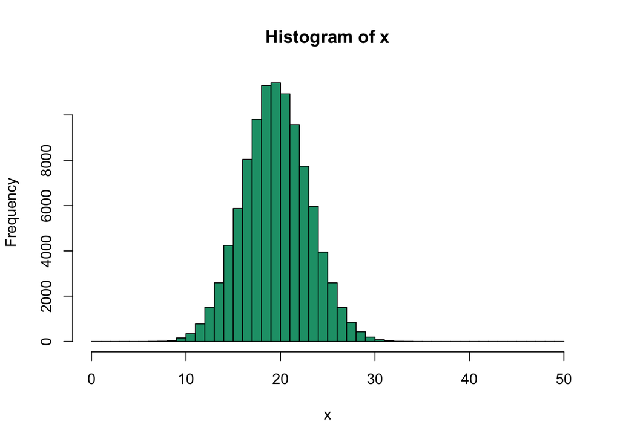

```r
library(RColorBrewer)
pal <- brewer.pal(8, "Dark2")
x <- rbinom(100000, size = 50, prob = 0.4)
hist(x, breaks = c(0:50), col = pal[1])
```

Notice that, the quantile function $q(p)$ is the smallest $x$ such that $F(x) \ge p$.

## Normal Distribution

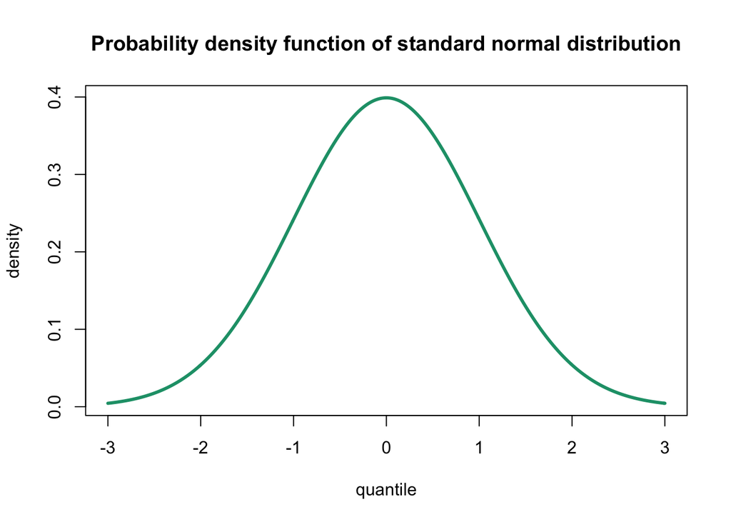

```r
x1 <- (-300:300)/100
plot(x1, dnorm(x1), col = pal[1], type = "l", lwd = 3, xlab = "quantile", ylab = "density",
     main = "Probability density function of standard normal distribution")
```

```r
2 * pnorm(c(1, 2, 3)) - 1
```

```
## [1] 0.6826895 0.9544997 0.9973002
```

Example: the symmetric interval that covers 90% area of the density of $X = 3Z + 2$ is?

```r
qnorm(p = c(0.05, 0.95), mean = 2, sd = 3)
```

```
## [1] -2.934561  6.934561
```